# The Impact of Natural Disaster in United States

Zahiruddin Zahidanishah

06/06/2020

## Synopsis

Natural disasters are unpredictable, deadly, and destructive. The sheer size and geographic diversity of the United States means that the country experiences a variety of different natural disasters on a frequent basis. This study is based on the data set from year 1950 to 2011. This study shows that the most fatality natural disaster in United States is tornado. Natural disaster also has caused major destructive damages and this study focused on two main damages, which are property damages and crop damages. Hopefully, this study will assist all stakeholder to take necessary action and precaution in reducing the number of damages caused by natural disaster to the overall population in United States.

## Introduction

Storms and other severe weather events can cause both public health and economic problems for communities and municipalities. Many severe events can result in fatalities, injuries, and property damage, and preventing such outcomes to the extent possible is a key concern.

This project involves exploring the U.S. National Oceanic and Atmospheric Administration’s (NOAA) storm database. This database tracks characteristics of major storms and weather events in the United States, including when and where they occur, as well as estimates of any fatalities, injuries, and property damage.

The events in the database start in the year 1950 and end in November 2011. In the earlier years of the database there are generally fewer events recorded, most likely due to a lack of good records.

## Code Programming Setting

The basic programming setting is used to ensure that all required packages to perform the code programming is installed at the beginning stage. The following R packages has been selected in order to perform the programming code for this report.

```r
library(knitr)
library(markdown)
library(rmarkdown)
library(plyr)
library(stats)
```

## Data Processing

Before any calculation and analysis of the data set, the data will be integrate with the R program through the following codes. The data set will be the part of the programming.

The numbers of rows and columns of the data sets are also identified at this stage in order to understand the amount of the data set.

```r
stormdata <- read.csv(file = "repdata-data-StormData.csv", header = TRUE, sep = ",")
dim(stormdata)
```

```
## [1] 902297     37
```

Based on the above shows that there are total 37 columns in the data set and the names of each column are as detail below:-

```r
names(stormdata)
```

```
##  [1] "STATE__"    "BGN_DATE"   "BGN_TIME"   "TIME_ZONE"  "COUNTY"
##  [6] "COUNTYNAME" "STATE"      "EVTYPE"     "BGN_RANGE"  "BGN_AZI"
## [11] "BGN_LOCATI" "END_DATE"   "END_TIME"   "COUNTY_END" "COUNTYENDN"
## [16] "END_RANGE"  "END_AZI"    "END_LOCATI" "LENGTH"     "WIDTH"
## [21] "F"          "MAG"        "FATALITIES" "INJURIES"   "PROPDMG"
## [26] "PROPDMGEXP" "CROPDMG"    "CROPDMGEXP" "WFO"        "STATEOFFIC"
## [31] "ZONENAMES"  "LATITUDE"   "LONGITUDE"  "LATITUDE_E" "LONGITUDE_"
## [36] "REMARKS"    "REFNUM"
```

Based on the data set column name, it can be concluded that the following variables that will be used for calculation in order to identify the affect of natural disaster in United States.

The following are the main variables to be used based on the data set:-

1. “EVTYPE” : Event Type
2. “FATALITIES” : Number of Fatalities
3. “INJURIES” : Number of Injuries
4. “PROPDMG” : Property Damage
5. “PROPDMGEXP” : Units for Property Damage
6. “CROPDMG” : Crop Damage
7. “CROPDMGEXP” : Units for Crop Damage

```
##  [1] "K" "M" ""  "B" "m" "+" "0" "5" "6" "?" "4" "2" "3" "h" "7" "H" "-" "1" "8"
```

```
## [1] ""  "M" "K" "m" "B" "?" "0" "k" "2"
```

## Observation No.1: The Impact of Natural Disaster Against Health Population in United States

Based on the given data set, the following shows the top five (5) total number of fatalities cases based on the natural disaster events:-

```
##             EVTYPE FATALITIES
## 834        TORNADO       5633
## 130 EXCESSIVE HEAT       1903
## 153    FLASH FLOOD        978
## 275           HEAT        937
## 464      LIGHTNING        816
```

The following shows the barplot of the five (5) most fatal cases of natural disaster in United States:-

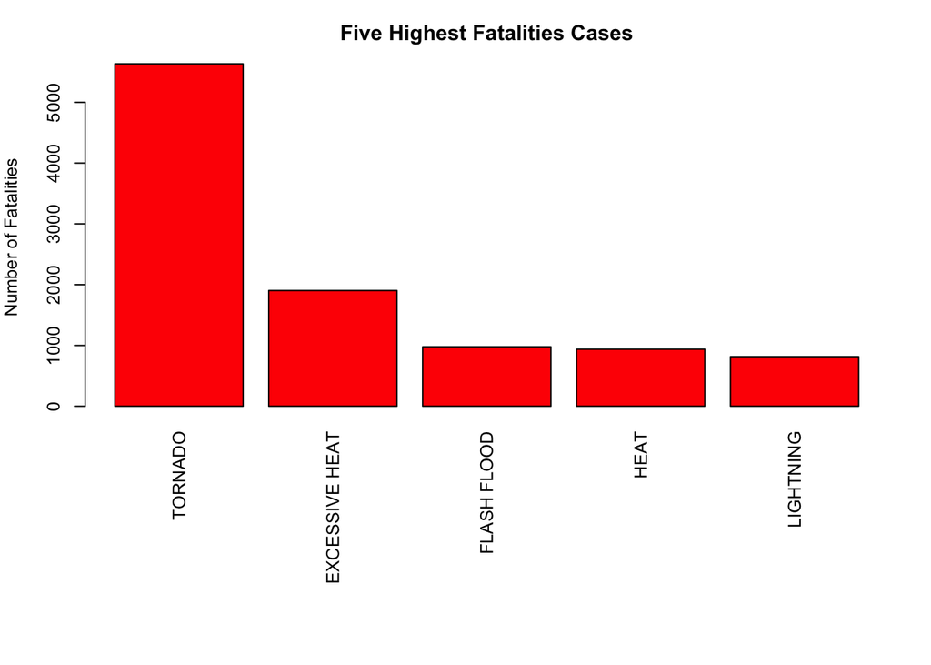

```r
par(mfrow = c(1,1), mar = c(12, 4, 3, 2), mgp = c(3, 1, 0), cex = 0.8)
barplot(fatalitiesevents$FATALITIES, names.arg = fatalitiesevents$EVTYPE, las = 3, main = "Five Highest Fatalities Cases", ylab = "Number of Fatalities", col="red")
```

Based on the data set, the following shows the top five (5) total number of injury cases based on the type of natural disaster events in United States:-

```
##             EVTYPE INJURIES
## 834        TORNADO    91346
## 856      TSTM WIND     6957
## 170          FLOOD     6789
## 130 EXCESSIVE HEAT     6525
## 464      LIGHTNING     5230
```

The following shows the barplot of the top five injury cases based on natural disaster events in United States:-

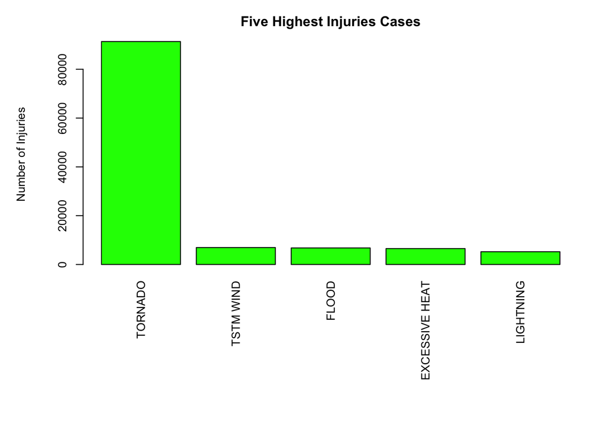

## Observation No.2: The Impact of Natural Disaster Against Economics Aspect in United States

Based on the data set, the following are the top five (5) high impact on the economic aspect based on the natural disaster events:-

```
##                EVTYPE PROPDMGTOTAL
## 170             FLOOD    144.65771
## 411 HURRICANE/TYPHOON     69.30584
## 834           TORNADO     56.94738
## 670       STORM SURGE     43.32354
## 153       FLASH FLOOD     16.82267
```

The following are the barplot showing the top five (5) high impact on the economic aspect based on the natural disaster events:-

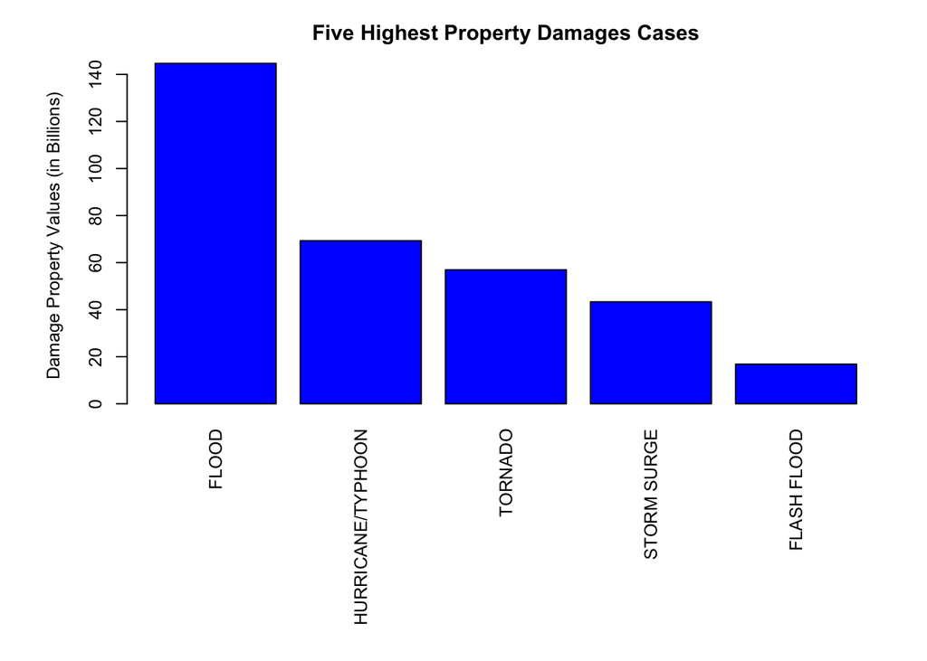

```r
par(mfrow = c(1,1), mar = c(12, 6, 3, 2), mgp = c(3, 1, 0), cex = 0.8)
barplot(propdmgTotal$PROPDMGTOTAL, names.arg = propdmgTotal$EVTYPE, las = 3, main = "Five Highest Property Damages Cases", ylab = "Damage Property Values (in Billions)", col="blue")
```

The following shows the top five (5) natural disasters that causing the damages in crop events:-

```
##          EVTYPE CROPDMGTOTAL
## 95      DROUGHT    13.972566
## 170       FLOOD     5.661968
## 590 RIVER FLOOD     5.029459
## 427   ICE STORM     5.022113
## 244        HAIL     3.025954
```

The following are the barplot showing the top five (5) natural disaster events that causing the damages in crop events:-

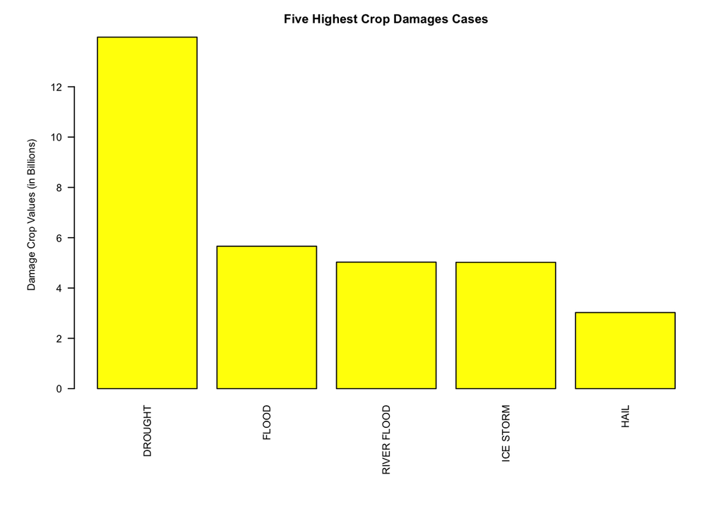

```r
par(mfrow = c(1,1), mar = c(10, 6, 3, 2), mgp = c(3, 1, 0), cex = 0.6)
barplot(cropdmgTotal$CROPDMGTOTAL, names.arg = cropdmgTotal$EVTYPE, las = 2, main = "Five Highest Crop Damages Cases", ylab = "Damage Crop Values (in Billions)", col="yellow")
```

## Conclusion

The data set shows that the natural disaster events in the United States have caused negative impact towards human and properties.

Based on observation and finding in the data analysis against the types of natural disaster, it can be conclude that:-

1. Tornado natural disaster has the most fatality and injury cases.
2. Flood natural disaster has the most losses in property damages.
3. Drought natural disaster has the most losses in crop damages.

In view of this findings, the government and all stakeholders shall take necessary action and precaution to reduced the negative impact in the future against the natural disaster. A further study is required to explore in detail on this issues.